# Data Preperation

Siyang Ni

2024-02-28

## Data Description

The dataset is from a longgitudinal social survey in the UK called the “Millennium Cohort Study” (MCS). The MCS follows the lives of around 19,000 young people born in England, Scotland, Wales, and Northern Ireland in 2000-02.

MCS provides multiple measures of the cohort members’ physical, socio-emotional, cognitive and behavioral development over time, as well as detailed information on their daily life, behavior and experiences. Alongside this, rich information on economic circumstances, parenting, relationships and family life is available from both resident parents.

Currently, the MCS have seven waves available to researchers. The first wave of survey was taken at the year 2001, when respondents were nine-month old. The seventh wave survey was taken at 2018, when the respondents were seventeen-year-old.

## Tasks

We will conduct the following task:

1. Merge the seven waves of data.
2. Provide a general description of the contents of your sample.
3. Identify issues that may need to be addressed in later analyses.
4. Exploratory data visualization
5. Some very basic exploratory data analysis

Computing Environment:

-Program: R 4.3.2 -IDE: R Studio Server 2023.12.1+402 “Ocean Storm” Release -OS: Ubuntu 22.04.4 LTS through WSL2 (x86_64-pc-linux-gnu)

## Loading and Merging

```r
setwd("/home/freeyang/research/hdfs597")

# install.packages('pacman')
# Pacman is an efficient R package manager, works like APT in Debian
library(pacman)

# For merging we need haven and dplyrgit config --global user.email "youremail@domain.com"
pacman::p_load(haven, dplyr)
```

```r
# Load all waves

## Base directory prefix
base_dir <- "/home/freeyang/research_data/mcs"

# Reading each wave, all column names to lowercase, filter out twins and triplets, keep only main caregivers.

# Wave 1 Parent Interview
wave1_parent_interview <- read_dta(file.path(base_dir, "MCS 1/stata11/mcs1_parent_interview.dta")) %>%
  rename_with(tolower)

# Wave 2 Child Assessment
wave2_child_assessment <- read_dta(file.path(base_dir, "MCS 2/stata11_se/mcs2_child_assessment_data.dta")) %>%
  rename_with(tolower) %>%
  filter(bhcnum00 == 1)

# Wave 2 Parent Interview
wave2_parent_interview <- read_dta(file.path(base_dir, "MCS 2/stata11_se/mcs2_parent_interview.dta")) %>%
  rename_with(tolower)

# Wave 3 Child Assessment
wave3_child_assessment <- read_dta(file.path(base_dir, "MCS 3/stata11_se/mcs3_child_assessment_data.dta")) %>%
  rename_with(tolower) %>%
  filter(chcnum00 == 1)

# Wave 3 Parent Interview
wave3_parent_interview <- read_dta(file.path(base_dir, "MCS 3/stata11_se/mcs3_parent_interview.dta")) %>%
  rename_with(tolower)

# Wave 4 Parent Interview
wave4_parent_interview <- read_dta(file.path(base_dir, "MCS 4/stata11_se/mcs4_parent_interview.dta")) %>%
  rename_with(tolower)

# Wave 4 Child Assessment
wave4_child_assessment <- read_dta(file.path(base_dir, "MCS 4/stata11_se/mcs4_cm_assessment.dta")) %>%
  rename_with(tolower) %>%
  filter(dccnum00 == 1)

# Wave 5 CM Assessment
wave5_cm_assessment <- read_dta(file.path(base_dir, "MCS 5/stata11/mcs5_cm_cognitive_assessment.dta")) %>%
  rename_with(tolower) %>%
  filter(ecnum00 == 1)

# Wave 5 CM Interview
wave5_cm_interview <- read_dta(file.path(base_dir, "MCS 5/stata11/mcs5_cm_interview.dta")) %>%
  rename_with(tolower) %>%
  filter(ecnum00 == 1)

# Wave 5 Parent CM Interview
wave5_parent_cm_interview <- read_dta(file.path(base_dir, "MCS 5/stata11/mcs5_parent_cm_interview.dta")) %>%
  rename_with(tolower) %>%
  filter(ecnum00 == 1, epnum00 == 1)

# Wave 5 Child Derived
wave5_child_derived <- read_dta(file.path(base_dir, "MCS 5/stata11/mcs5_cm_derived.dta")) %>%
  rename_with(tolower) %>%
  filter(ecnum00 == 1)

# Wave 6 CM Interview
wave6_cm_interview <- read_dta(file.path(base_dir, "MCS 6/stata11/mcs6_cm_interview.dta")) %>%
  rename_with(tolower) %>%
  filter(fcnum00 == 1)

# Wave 6 Parent CM Interview (Main)
wave6_parent_cm_interview <- read_dta(file.path(base_dir, "MCS 6/stata11/mcs6_parent_cm_interview.dta")) %>%
  rename_with(tolower) %>%
  filter(fpnum00 == 1, fcnum00 == 1)

# Wave 6 Parent Derived
wave6_parent_derived <- read_dta(file.path(base_dir, "MCS 6/stata11/mcs6_parent_derived.dta")) %>%
  rename_with(tolower) %>%
  filter(fpnum00 == 1)

# Wave 6 Child Derived
wave6_child_derived <- read_dta(file.path(base_dir, "MCS 6/stata11/mcs6_cm_derived.dta")) %>%
  rename_with(tolower) %>%
  filter(fcnum00 == 1)

# Wave 7 CM Interview
wave7_cm_interview <- read_dta(file.path(base_dir, "MCS 7/stata13/mcs7_cm_interview_onlyCM1.dta")) %>%
  rename_with(tolower)

# Wave 7 Parent CM Interview
wave7_parent_cm_interview <- read_dta(file.path(base_dir, "MCS 7/stata13/mcs7_parent_cm_interview.dta")) %>%
  rename_with(tolower) %>%
  filter(gpnum00 == 1, gcnum00 == 1)

# Wave 7 CM Derived
wave7_cm_derived <- read_dta(file.path(base_dir, "MCS 7/stata13/mcs7_cm_derived_onlyCM1.dta")) %>%
  rename_with(tolower)
```

```r
# Merge all waves

## purrr package for merging
pacman::p_load(purrr)

## Store all waves in a list
data_frames_list <- list(
  wave1_parent_interview,
  wave2_child_assessment,
  wave2_parent_interview,
  wave3_child_assessment,
  wave3_parent_interview,
  wave4_parent_interview,
  wave4_child_assessment,
  wave5_cm_assessment,
  wave5_cm_interview,
  wave5_parent_cm_interview,
  wave5_child_derived,
  wave6_cm_interview,
  wave6_parent_cm_interview,
  wave6_parent_derived,
  wave6_child_derived,
  wave7_cm_interview,
  wave7_parent_cm_interview,
  wave7_cm_derived
)

## Use reduce from purrr to merge all waves 1 by 1
merged_data <- purrr::reduce(data_frames_list, full_join, by = "mcsid")

## Save the merged dataset as an RDS file
### (Uncomment when needed)
#saveRDS(merged_data, file = "/home/freeyang/research_data/mcs/merging/merged_dataset.rds")
```

## Data Exploration

A quick look shows we have a very large dataset with 19,243 rows and 18,816 columns, and also many missing cases. This is expected for a panel data that span from when the respondents were nine-month-old to seventeen-year-old.

```r
## Load the merged dateset
merged_data <- readRDS(file = "/home/freeyang/research_data/mcs/merging/merged_dataset.rds")

## Summarize the data
dim(merged_data)
```

```
## [1] 19243 18816
```

```r
head(merged_data[1:5, 1:10])
```

```
## # A tibble: 5 × 10
##   mcsid  ahintm00 ahinty00 ahisex00 ahrepr00 ahnohh00 ahnoba00 ahcnhh00 ahbage00
##   <chr>  <dbl+lb> <dbl+lb> <dbl+lb> <dbl+lb> <dbl+lb> <dbl+lb> <dbl+lb> <dbl+lb>
## 1 M1000… 1        2002     1 [Male] 3 [No -… 7        1 [One … 6        290
## 2 M1000… 1        2002     2 [Fema… 3 [No -… 4        1 [One … 3        298
## 3 M1000… 8        2001     2 [Fema… 3 [No -… 3        1 [One … 2        297
## 4 M1000… 9        2001     1 [Male] 3 [No -… 5        2 [Twin… 3        293
## 5 M1001… 9        2001     2 [Fema… 3 [No -… 4        1 [One … 3        291
## # ℹ 1 more variable: ahptpc00 <dbl+lbl>
```

```r
## Missing Values
total_missing_values <- sum(is.na(merged_data))
cat("Total Missing Values:", total_missing_values, "\n")
```

```
## Total Missing Values: 90325177
```

Our main target variable is adolescent aggressive behaviors. We look at these variables in each waves, strating with the most recent wave 7 (age 17):

```r
# Show frequency distribution for variables measuring aggression at age 17
aggg_7 <- c("gpsdfb00", "gchitt00", "gcwepn00", "gcsdql00")

freq_tables <- lapply(merged_data[aggg_7], table)

lapply(names(freq_tables), function(x) {
  cat("\nFrequency table for", x, ":\n")
  print(freq_tables[[x]])
})
```

```
##
## Frequency table for gpsdfb00 :
##
##   -1    1    2    3    4
## 1207 7367  242   91   76
##
## Frequency table for gchitt00 :
##
##    1    2    3    4    5
## 2431 7546    4   17  240
##
## Frequency table for gcwepn00 :
##
##    1    2    3    4    5
##  104 9872    6   16  240
##
## Frequency table for gcsdql00 :
##
##   -9   -1    1    2    3
##   32  475 8332 1234  165
```

```
## [[1]]
##
##   -1    1    2    3    4
## 1207 7367  242   91   76
##
## [[2]]
##
##    1    2    3    4    5
## 2431 7546    4   17  240
##
## [[3]]
##
##    1    2    3    4    5
##  104 9872    6   16  240
##
## [[4]]
##
##   -9   -1    1    2    3
##   32  475 8332 1234  165
```

In the following code chunk, we recode these variables by comining missing value categories and adding variable labels. Finally, we show the frequency of each variables again.

```
##
## Variable: agr7_fig
```

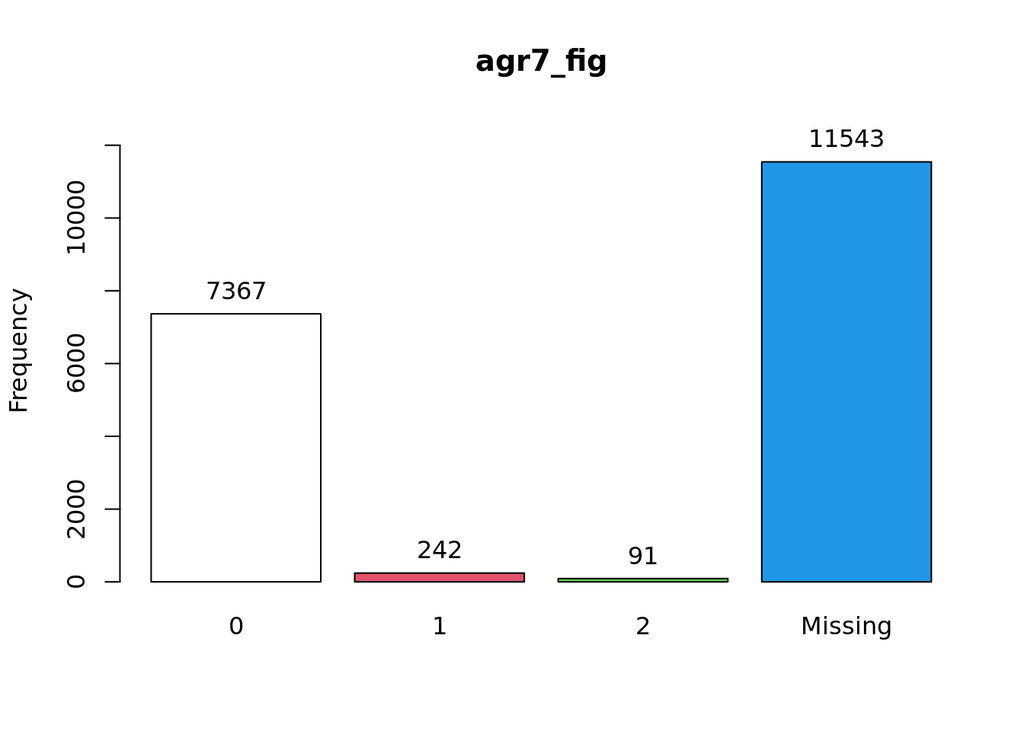

```
##
## Variable: agr7_hit
```

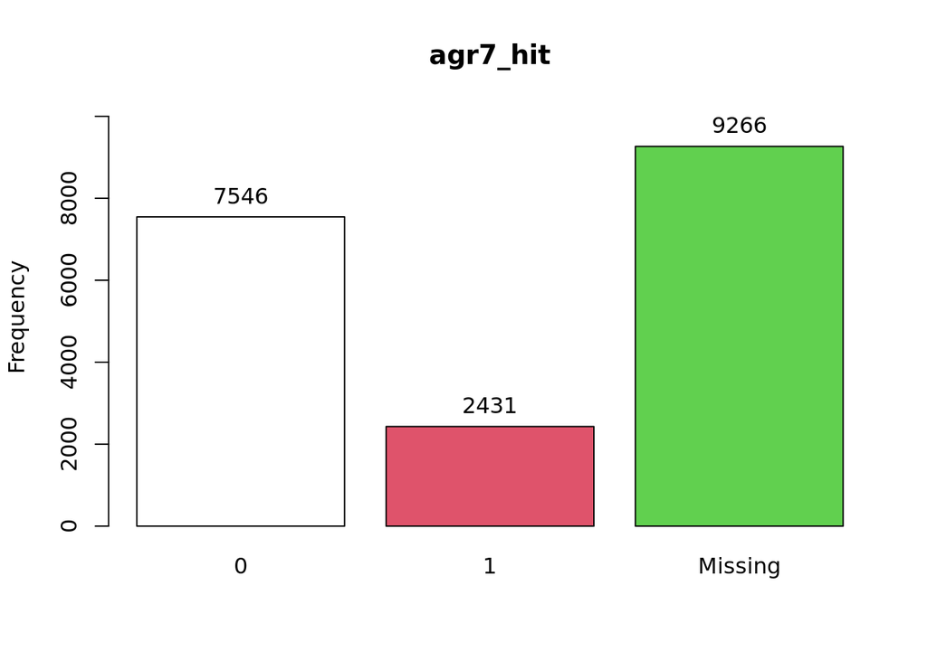

```
##
## Variable: agr7_wepn
```

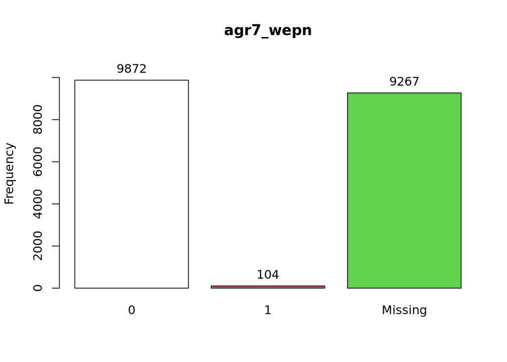

```
##
## Variable: agr7_srfig
```

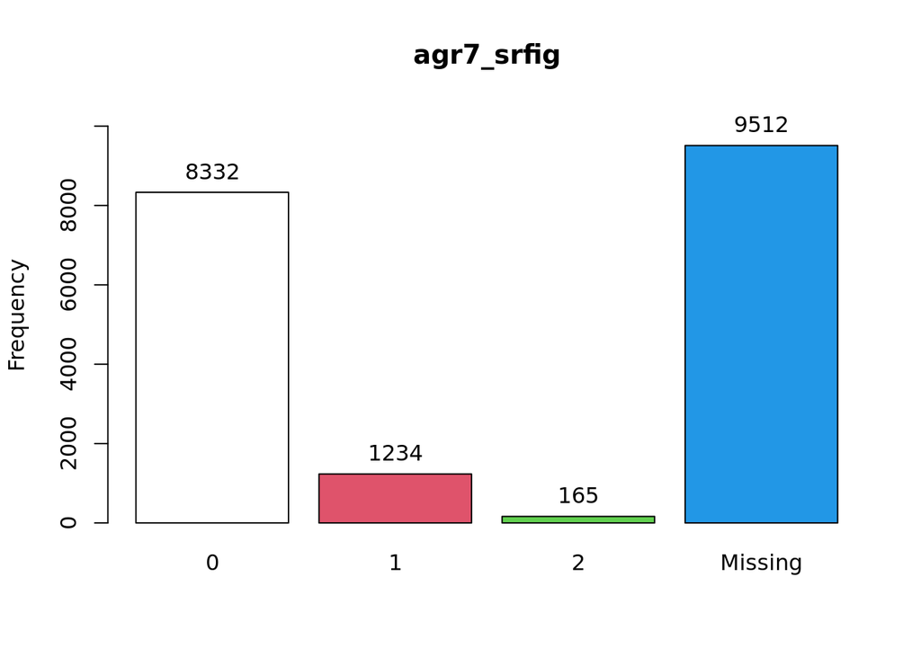

```
## [[1]]
## df1[, var_name] :
##         Frequency   %(NA+)   %(NA-)
## 0            7367     38.3     95.7
## 1             242      1.3      3.1
## 2              91      0.5      1.2
## <NA>        11543     60.0      0.0
##   Total     19243    100.0    100.0
##
## [[2]]
## df1[, var_name] :
##         Frequency   %(NA+)   %(NA-)
## 0            7546     39.2     75.6
## 1            2431     12.6     24.4
## <NA>         9266     48.2      0.0
##   Total     19243    100.0    100.0
##
## [[3]]
## df1[, var_name] :
##         Frequency   %(NA+)   %(NA-)
## 0            9872     51.3       99
## 1             104      0.5        1
## <NA>         9267     48.2        0
##   Total     19243    100.0      100
##
## [[4]]
## df1[, var_name] :
##         Frequency   %(NA+)   %(NA-)
## 0            8332     43.3     85.6
## 1            1234      6.4     12.7
## 2             165      0.9      1.7
## <NA>         9512     49.4      0.0
##   Total     19243    100.0    100.0
```

```r
# Package for label and the tab1 function
pacman::p_load(labelled, epiDisplay)

# Function to apply the recoding based on specific rules
recode_var <- function(var, rules) {
  case_when(
    var %in% rules$from ~ rules$to[match(var, rules$from)],
    TRUE ~ NA_real_  # Default case to NA for unspecified values
  )
}

# Recoding for each variables
df1 <- merged_data %>%
  dplyr::select(gpsdfb00, gchitt00, gcwepn00, gcsdql00) %>%
  mutate(
    agr7_fig = recode_var(gpsdfb00, tibble(from = c(-1, 4, 1, 2, 3), to = c(NA, NA, 0, 1, 2))),
    agr7_hit = recode_var(gchitt00, tibble(from = c(3, 4, 5, 2, 1), to = c(NA, NA, NA, 0, 1))),
    agr7_wepn = recode_var(gcwepn00, tibble(from = c(3, 4, 5, 2, 1), to = c(NA, NA, NA, 0, 1))),
    agr7_srfig = recode_var(gcsdql00, tibble(from = c(-9, -1, 1, 2, 3), to = c(NA, NA, 0, 1, 2)))
  ) %>%
  dplyr::select(agr7_fig, agr7_hit, agr7_wepn, agr7_srfig) %>%
  labelled::set_variable_labels(
    agr7_fig = "Fight with others",
    agr7_hit = "Pushed or shoved/hit/slapped/punched someone",
    agr7_wepn = "Used or hit someone with a weapon",
    agr7_srfig = "I fight a lot"
  )

# Variables to analyze
agr7 <- c("agr7_fig", "agr7_hit", "agr7_wepn", "agr7_srfig")

# A quick look at each variable
lapply(agr7, function(var_name) {
  cat("\nVariable:", var_name, "\n")
  tab1(df1[, var_name], main = var_name)
})
```

Now, we look at variables for adolescent aggresive behaviors in wave 6 (age 14).

```r
# Show frequency distribution for variables measuring aggression at age 14
aggg_6 <- c("fpsdfb00", "fchitt00", "fcwepn00", "fcbulp00", "fcpckp00")

freq_tables <- lapply(merged_data[aggg_6], table)

lapply(names(freq_tables), function(x) {
  cat("\nFrequency table for", x, ":\n")
  print(freq_tables[[x]])
})
```

```
##
## Frequency table for fpsdfb00 :
##
##   -9   -1    1    2    3
##   54  826 9429  556  140
##
## Frequency table for fchitt00 :
##
##   -9   -8   -1    1    2
##   23   10  500 3405 7788
##
## Frequency table for fcwepn00 :
##
##    -9    -8    -1     1     2
##    23     8   500   105 11090
##
## Frequency table for fcbulp00 :
##
##   -9   -8   -1    1    2    3    4    5    6    7
##    6    6 1246  967 1541  774  551 2879 3744   12
##
## Frequency table for fcpckp00 :
##
##   -9   -8   -1    1    2    3    4    5    6
##   29   10  500   85  214  217  263 2330 8078
```

```
## [[1]]
##
##   -9   -1    1    2    3
##   54  826 9429  556  140
##
## [[2]]
##
##   -9   -8   -1    1    2
##   23   10  500 3405 7788
##
## [[3]]
##
##    -9    -8    -1     1     2
##    23     8   500   105 11090
##
## [[4]]
##
##   -9   -8   -1    1    2    3    4    5    6    7
##    6    6 1246  967 1541  774  551 2879 3744   12
##
## [[5]]
##
##   -9   -8   -1    1    2    3    4    5    6
##   29   10  500   85  214  217  263 2330 8078
```

```
##
## Variable: agr6_fig
```

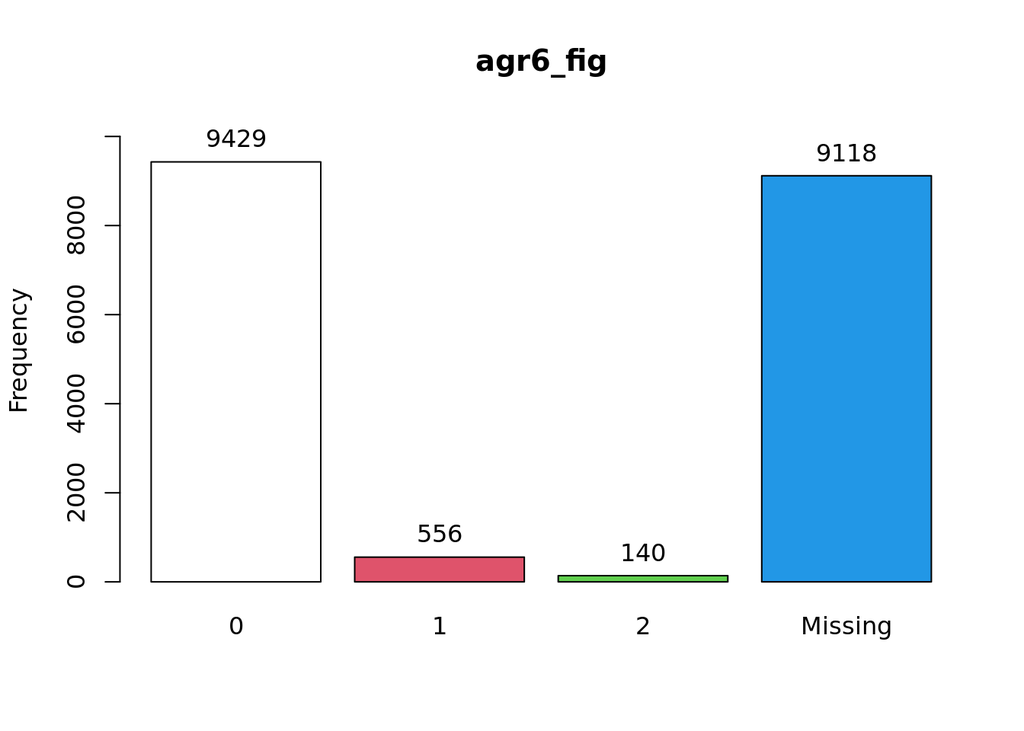

```
##
## Variable: agr6_hit
```

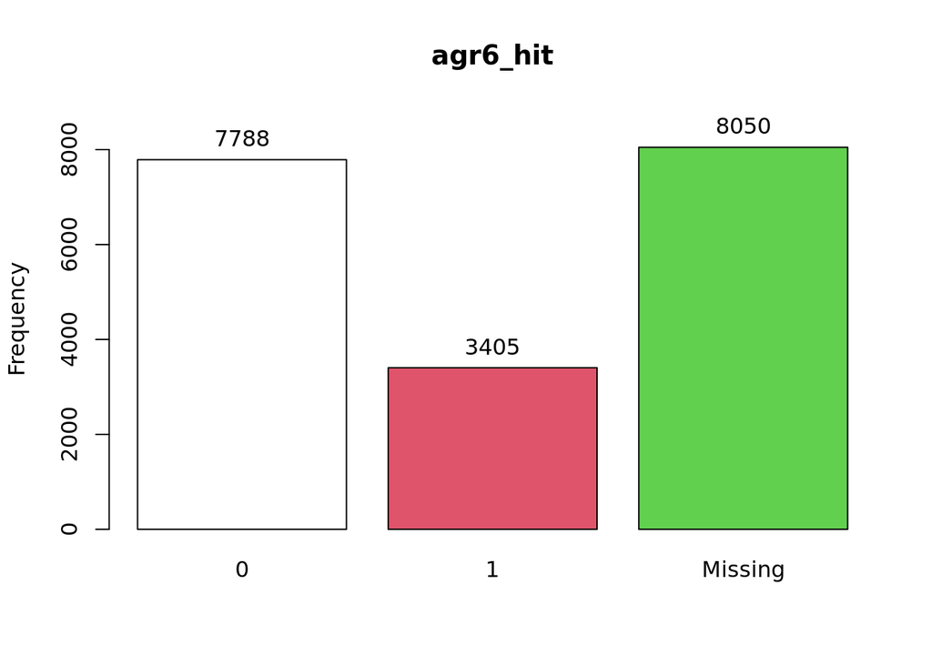

```
##
## Variable: agr6_wepn
```

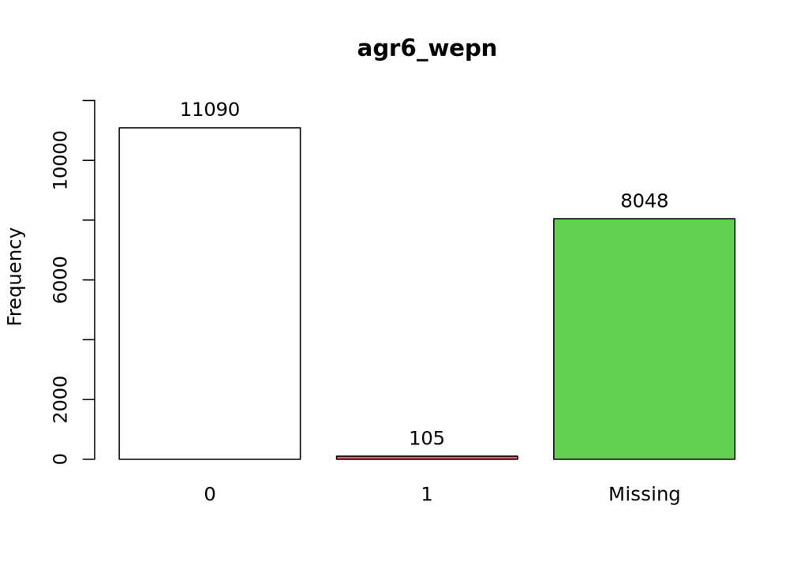

```
##
## Variable: agr6_hps
```

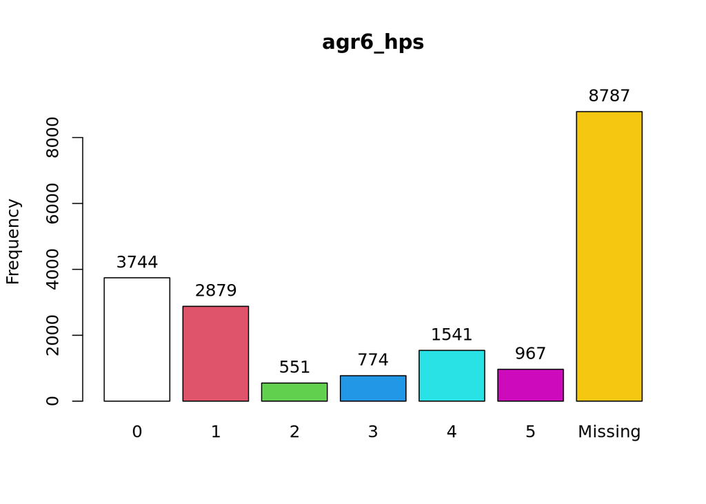

```
##
## Variable: agr6_hpc
```

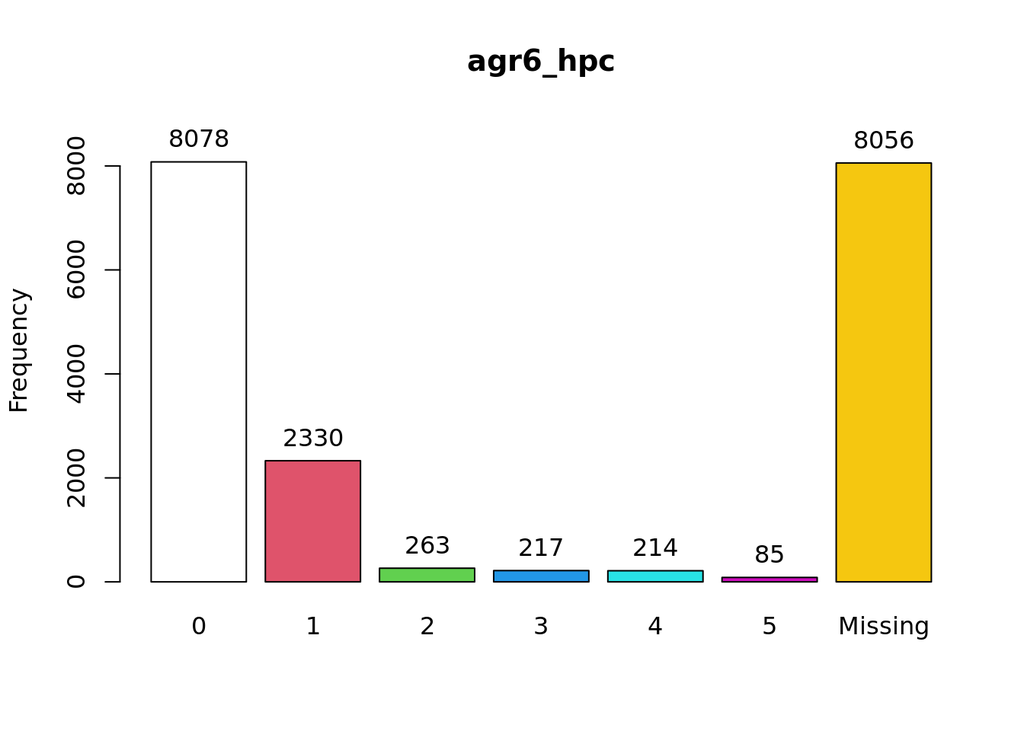

```
## [[1]]
## df2[, var_name] :
##         Frequency   %(NA+)   %(NA-)
## 0            9429     49.0     93.1
## 1             556      2.9      5.5
## 2             140      0.7      1.4
## <NA>         9118     47.4      0.0
##   Total     19243    100.0    100.0
##
## [[2]]
## df2[, var_name] :
##         Frequency   %(NA+)   %(NA-)
## 0            7788     40.5     69.6
## 1            3405     17.7     30.4
## <NA>         8050     41.8      0.0
##   Total     19243    100.0    100.0
##
## [[3]]
## df2[, var_name] :
##         Frequency   %(NA+)   %(NA-)
## 0           11090     57.6     99.1
## 1             105      0.5      0.9
## <NA>         8048     41.8      0.0
##   Total     19243    100.0    100.0
##
## [[4]]
## df2[, var_name] :
##         Frequency   %(NA+)   %(NA-)
## 0            3744     19.5     35.8
## 1            2879     15.0     27.5
## 2             551      2.9      5.3
## 3             774      4.0      7.4
## 4            1541      8.0     14.7
## 5             967      5.0      9.2
## <NA>         8787     45.7      0.0
##   Total     19243    100.0    100.0
##
## [[5]]
## df2[, var_name] :
##         Frequency   %(NA+)   %(NA-)
## 0            8078     42.0     72.2
## 1            2330     12.1     20.8
## 2             263      1.4      2.4
## 3             217      1.1      1.9
## 4             214      1.1      1.9
## 5              85      0.4      0.8
## <NA>         8056     41.9      0.0
##   Total     19243    100.0    100.0
```

```r
# Recoding for each variables
df2 <- merged_data %>%
  mutate(
    agr6_fig = recode_var(fpsdfb00, tibble(from = c(-1, -9, 1, 2, 3), to = c(NA, NA, 0, 1, 2))),
    agr6_hit = recode_var(fchitt00, tibble(from = c(-9, -8, -1, 2, 1), to = c(NA, NA, NA, 0, 1))),
    agr6_wepn = recode_var(fcwepn00, tibble(from = c(-9, -8, -1, 2, 1), to = c(NA, NA, NA, 0, 1))),
    agr6_hps = recode_var(fcbulp00, tibble(from = c(-9, -8, -1, 7, 6, 5, 4, 3, 2, 1), to = c(NA, NA, NA, NA, 0, 1, 2, 3, 4, 5))),
    agr6_hpc = recode_var(fcpckp00, tibble(from = c(-9, -8, -1, 6, 5, 4, 3, 2, 1), to = c(NA, NA, NA, 0, 1, 2, 3, 4, 5))),
  ) %>%
  labelled::set_variable_labels(
    agr6_fig = "Fight with others",
    agr6_hit = "Pushed or shoved/hit/slapped/punched someone",
    agr6_wepn = "Used or hit someone with a weapon",
    agr6_hps = "Hurt or pick on siblings",
    agr6_hpc = "Hurt or pick on other children") %>%
  dplyr::select(agr6_fig, agr6_hit, agr6_wepn, agr6_hps, agr6_hpc)

# Variables to analyze
agr6 <- c("agr6_fig", "agr6_hit", "agr6_wepn", "agr6_hps", "agr6_hpc")

# A quick look at each variable
lapply(agr6, function(var_name) {
  cat("\nVariable:", var_name, "\n")
  tab1(df2[, var_name], main = var_name)
})
```

Following the same logic, we take a look at the variables in wave 5 (age 11)

```r
# Aggression variables at age 14
aggg_5 <- c("epsdfb00", "ecq55x00", "ecq57x00")

freq_tables <- lapply(merged_data[aggg_5], table)

# Print frequency tables for each aggression variable
lapply(names(freq_tables), function(x) {
  cat("\nFrequency table for", x, ":\n")
  print(freq_tables[[x]])
})
```

```
##
## Frequency table for epsdfb00 :
##
##    -1     1     2     3     4
##   859 10946   702   145    76
##
## Frequency table for ecq55x00 :
##
##   -8    1    2    3    4    5    6    7
##  471 1417 2240  998  840 3023 3375  913
##
## Frequency table for ecq57x00 :
##
##   -8    1    2    3    4    5    6
##  465  140  263  340  389 2460 9220
```

```
## [[1]]
##
##    -1     1     2     3     4
##   859 10946   702   145    76
##
## [[2]]
##
##   -8    1    2    3    4    5    6    7
##  471 1417 2240  998  840 3023 3375  913
##
## [[3]]
##
##   -8    1    2    3    4    5    6
##  465  140  263  340  389 2460 9220
```

And then recode the three variables measuring adolescent aggression at wave 5 (age 11).

```
##
## Variable: agr5_fig
```

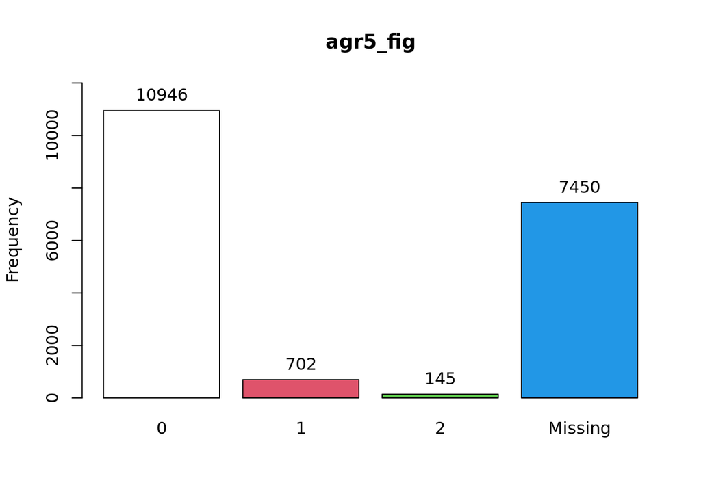

```
##
## Variable: agr5_hps
```

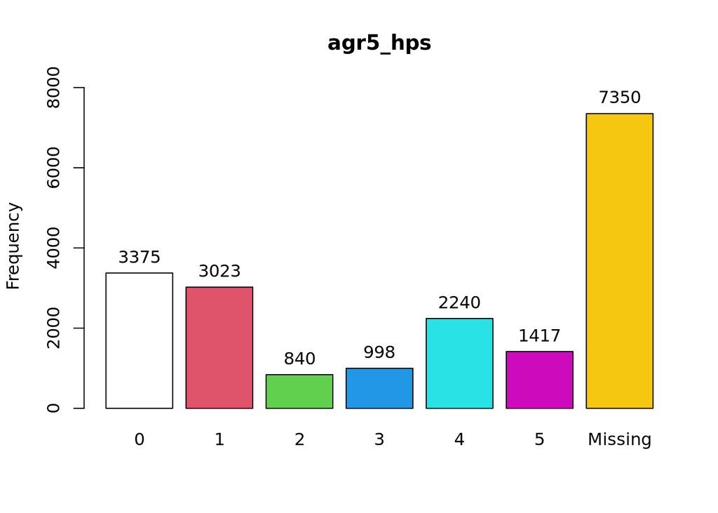

```
##
## Variable: agr5_hpc
```

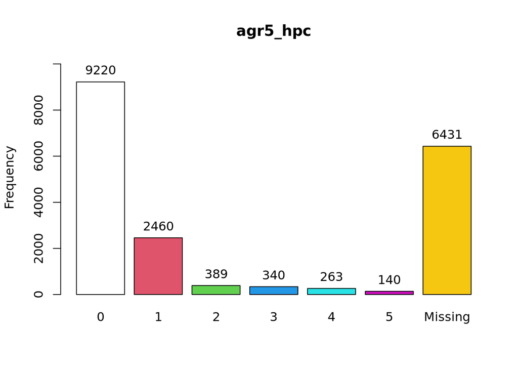

```
## [[1]]
## df3[, var_name] :
##         Frequency   %(NA+)   %(NA-)
## 0           10946     56.9     92.8
## 1             702      3.6      6.0
## 2             145      0.8      1.2
## <NA>         7450     38.7      0.0
##   Total     19243    100.0    100.0
##
## [[2]]
## df3[, var_name] :
##         Frequency   %(NA+)   %(NA-)
## 0            3375     17.5     28.4
## 1            3023     15.7     25.4
## 2             840      4.4      7.1
## 3             998      5.2      8.4
## 4            2240     11.6     18.8
## 5            1417      7.4     11.9
## <NA>         7350     38.2      0.0
##   Total     19243    100.0    100.0
##
## [[3]]
## df3[, var_name] :
##         Frequency   %(NA+)   %(NA-)
## 0            9220     47.9     72.0
## 1            2460     12.8     19.2
## 2             389      2.0      3.0
## 3             340      1.8      2.7
## 4             263      1.4      2.1
## 5             140      0.7      1.1
## <NA>         6431     33.4      0.0
##   Total     19243    100.0    100.0
```

```r
df3 <- merged_data %>%
  dplyr::select(epsdfb00, ecq55x00, ecq57x00) %>%
  mutate(
    # Recoding 'fight with others'
    agr5_fig = recode_var(epsdfb00, tibble(from = c(-1, 4, 1, 2, 3), to = c(NA, NA, 0, 1, 2))),
    # Recoding 'hurt or pick on siblings'
    agr5_hps = recode_var(ecq55x00, tibble(from = c(-8, 7, 6, 5, 4, 3, 2, 1), to = c(NA, NA, 0, 1, 2, 3, 4, 5))),
    # Recoding 'hurt or pick on other children'
    agr5_hpc = recode_var(ecq57x00, tibble(from = c(-8, 6, 5, 4, 3, 2, 1), to = c(NA, 0, 1, 2, 3, 4, 5)))
  ) %>%
  # Selecting the newly recoded variables for further analysis or inspection
  dplyr::select(agr5_fig, agr5_hps, agr5_hpc) %>%
  set_variable_labels(
  agr5_fig = "Fight with others",
  agr5_hps = "Hurt or pick on siblings",
  agr5_hpc = "Hurt or pick on other children"
)

# Show all variable frequency
agr5 <- c("agr5_fig", "agr5_hps", "agr5_hpc")

lapply(agr5, function(var_name) {
  cat("\nVariable:", var_name, "\n")
  tab1(df3[, var_name], main = var_name)
})
```

Now, combine all the adolescent aggression variables into one dataframe:

```r
df_aggr <- bind_rows(df1, df2, df3)
# Check dimensions
dim(df_aggr)
```

```
## [1] 57729    12
```

We ask how self-control affects adolescent aggressive behaviors. So, we need to look at self-control variables. In our study, we measure self-control from two dimensions: impulsivivity and unhealthy risk-taking behaviors. We look at hese variables in each wave.

We start by looking at wave 7 (age 17)

```
##
## Variable: imp7_tem
```

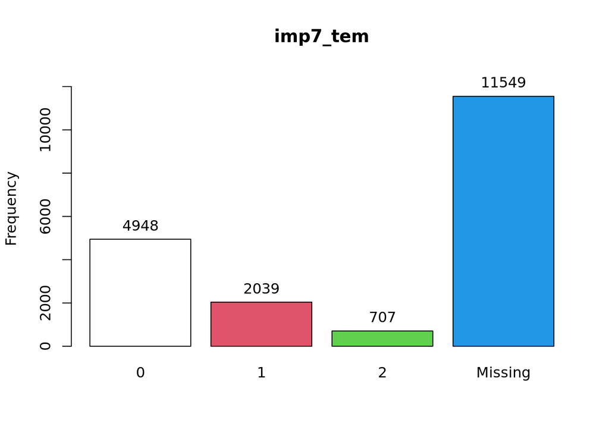

```
##
## Variable: imp7_res
```

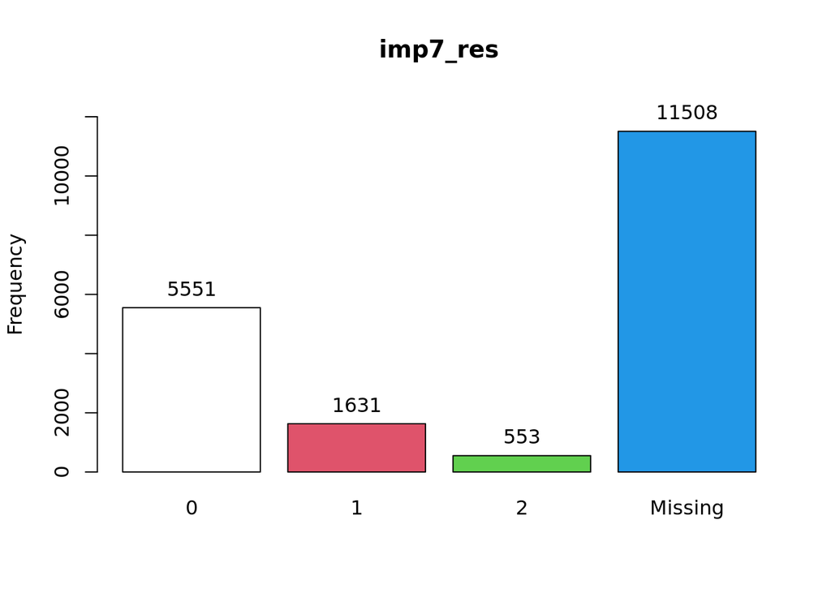

```
##
## Variable: imp7_fid
```

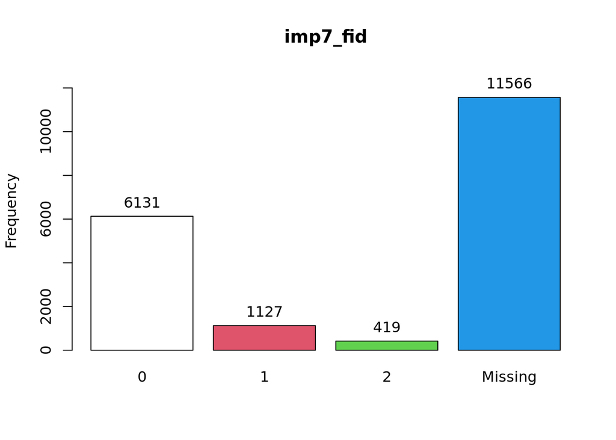

```
##
## Variable: imp7_dis
```

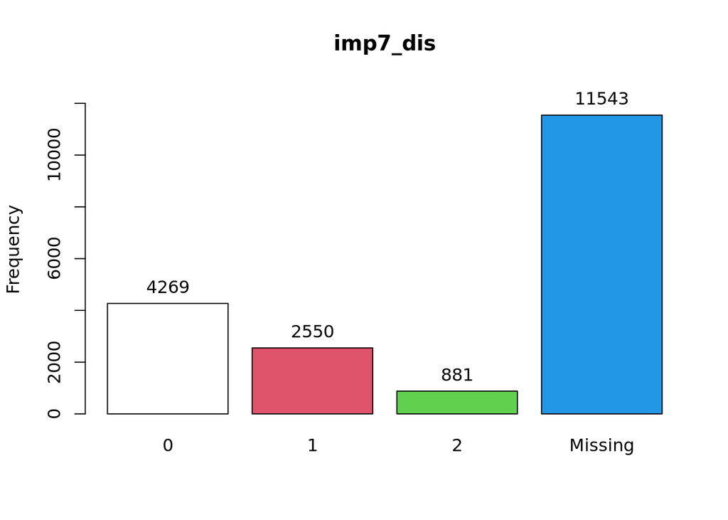

```
##
## Variable: imp7_thi
```

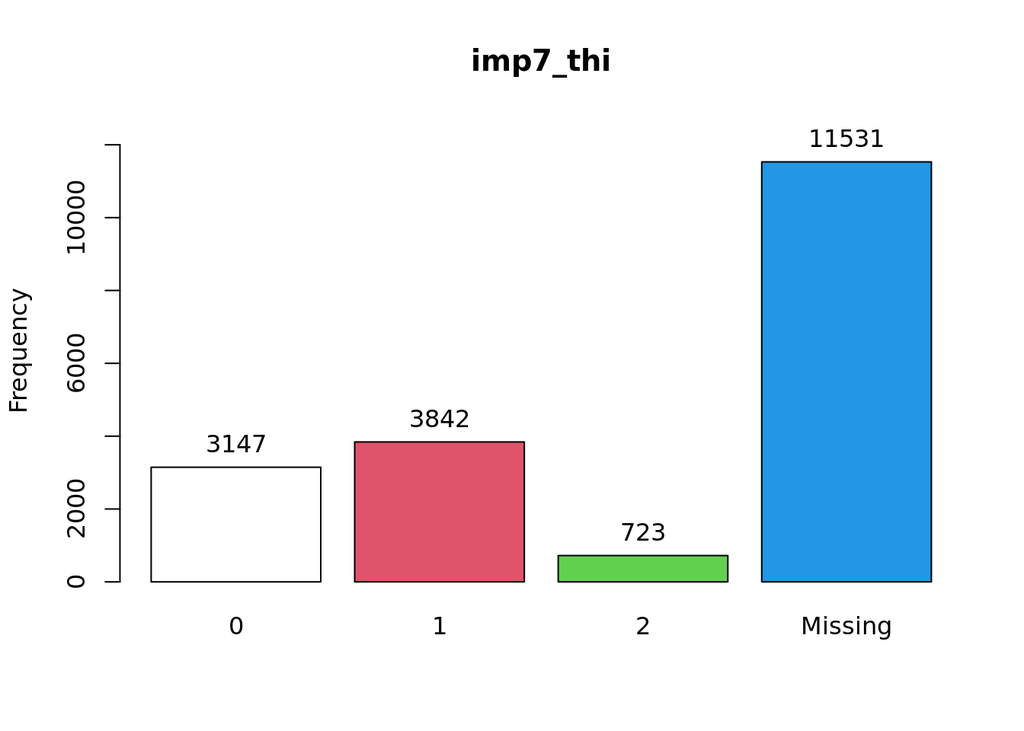

```
##
## Variable: imp7_tas
```

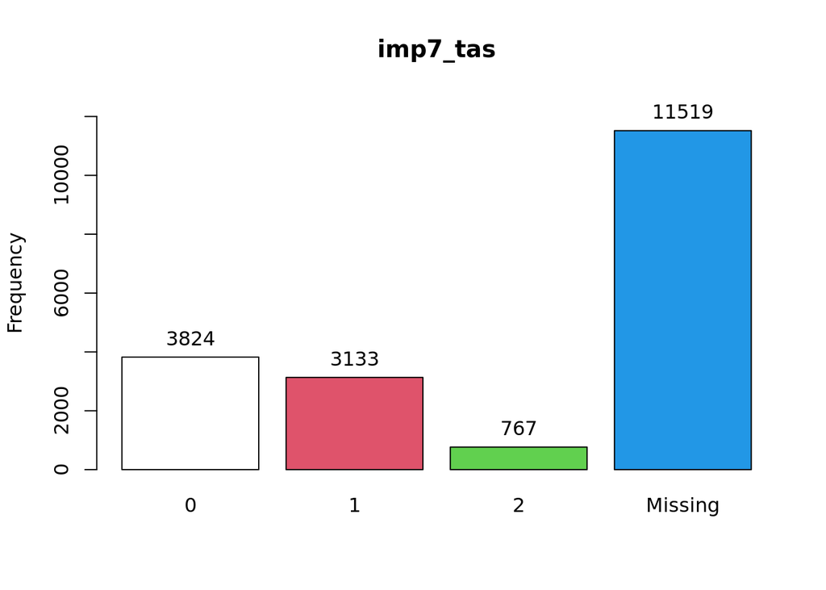

```
##
## Variable: risk7_lie
```

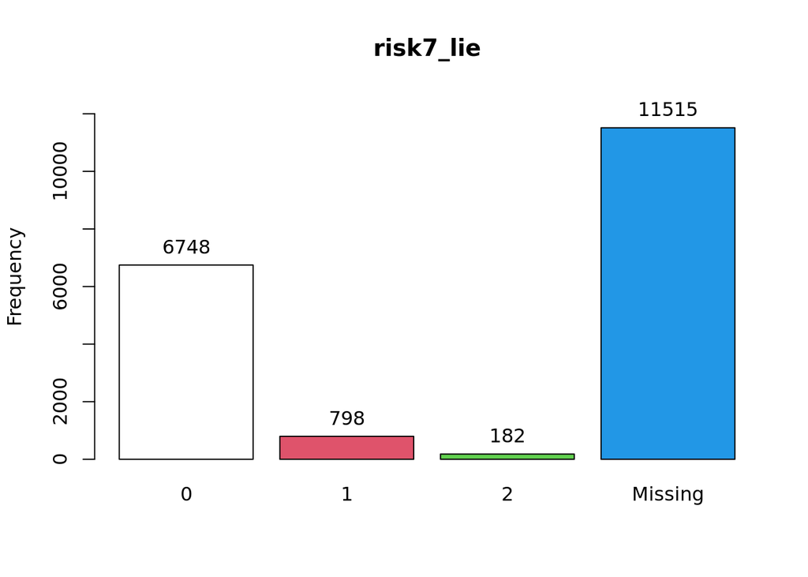

```
##
## Variable: risk7_ste
```

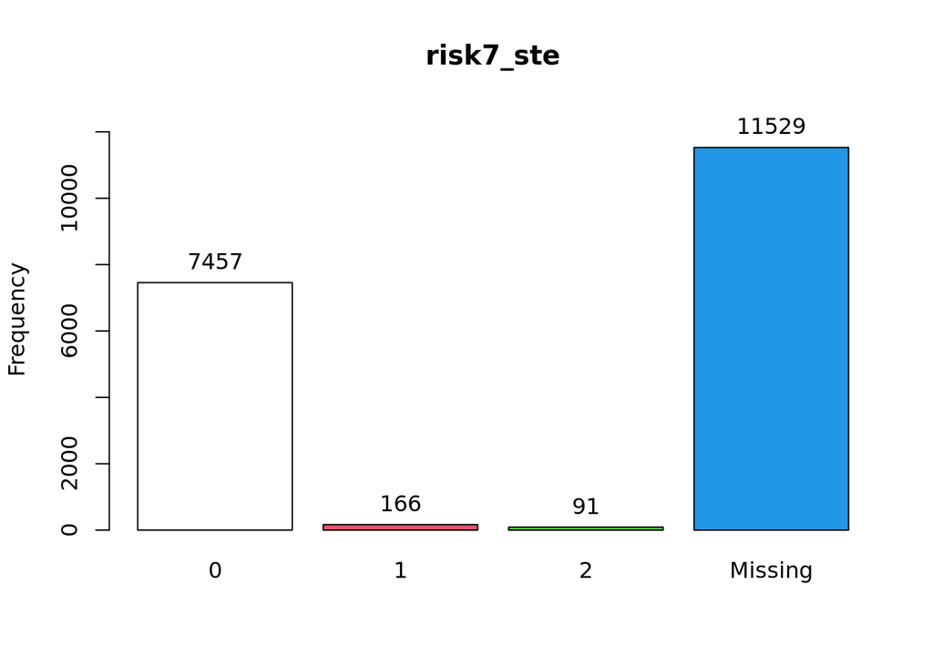

```
##
## Variable: risk7_obe
```

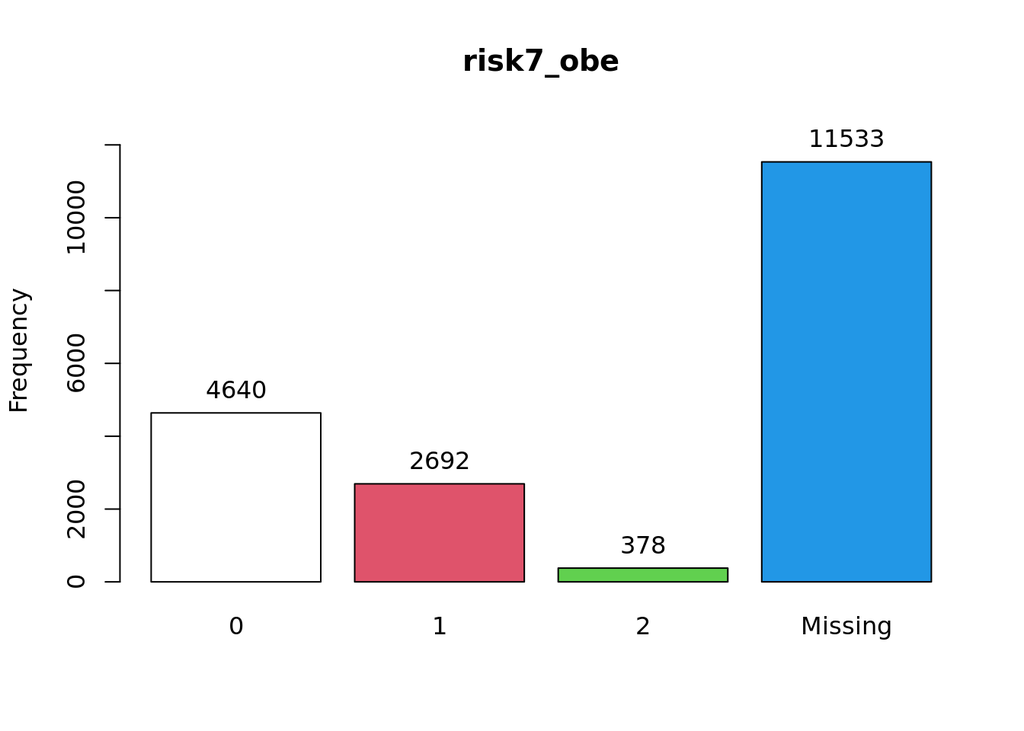

```
##
## Variable: risk7_shl
```

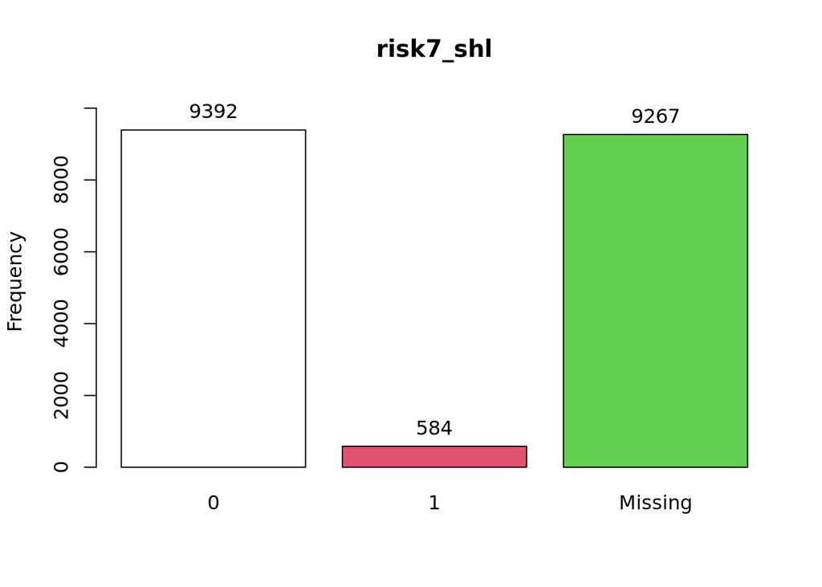

```
##
## Variable: risk7_wpp
```

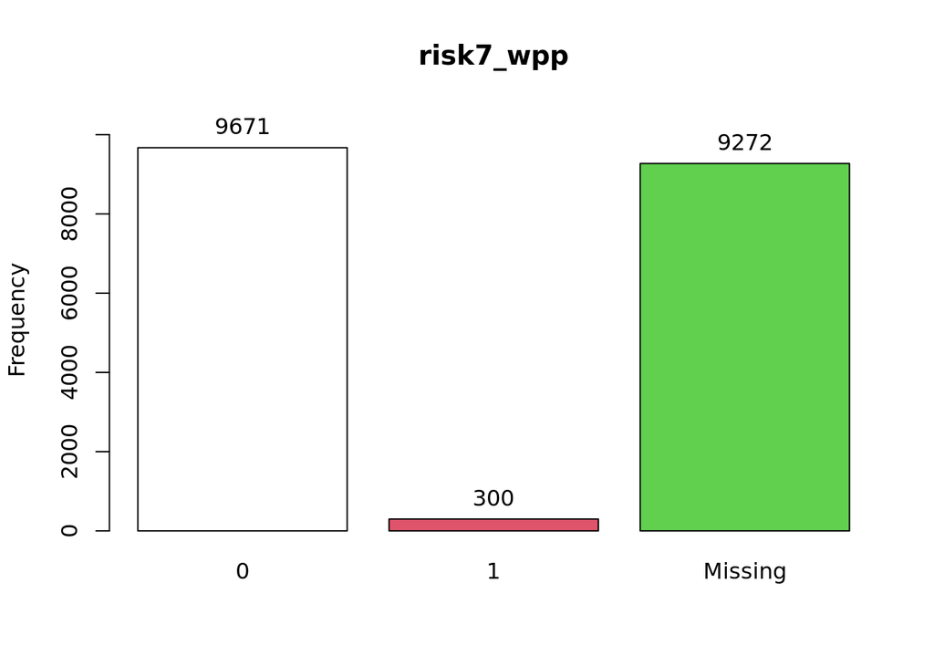

```
##
## Variable: risk7_smk
```

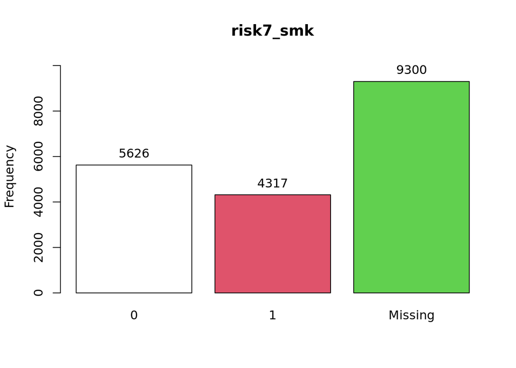

```
##
## Variable: risk7_drk
```

[2 more figures not shown]

```
## [[1]]
## df4[, var_name] :
##         Frequency   %(NA+)   %(NA-)
## 0            4948     25.7     64.3
## 1            2039     10.6     26.5
## 2             707      3.7      9.2
## <NA>        11549     60.0      0.0
##   Total     19243    100.0    100.0
##
## [[2]]
## df4[, var_name] :
##         Frequency   %(NA+)   %(NA-)
## 0            5551     28.8     71.8
## 1            1631      8.5     21.1
## 2             553      2.9      7.1
## <NA>        11508     59.8      0.0
##   Total     19243    100.0    100.0
##
## [[3]]
## df4[, var_name] :
##         Frequency   %(NA+)   %(NA-)
## 0            6131     31.9     79.9
## 1            1127      5.9     14.7
## 2             419      2.2      5.5
## <NA>        11566     60.1      0.0
##   Total     19243    100.0    100.0
##
## [[4]]
## df4[, var_name] :
##         Frequency   %(NA+)   %(NA-)
## 0            4269     22.2     55.4
## 1            2550     13.3     33.1
## 2             881      4.6     11.4
## <NA>        11543     60.0      0.0
##   Total     19243    100.0    100.0
##
## [[5]]
## df4[, var_name] :
##         Frequency   %(NA+)   %(NA-)
## 0            3147     16.4     40.8
```

[output cut: 65 more lines]

```
## [[13]]
## df4[, var_name] :
##         Frequency   %(NA+)   %(NA-)
## 0            2141     11.1     21.5
## 1            7838     40.7     78.5
## <NA>         9264     48.1      0.0
##   Total     19243    100.0    100.0
##
## [[14]]
## df4[, var_name] :
##         Frequency   %(NA+)   %(NA-)
## 0            9625     50.0     96.8
## 1             320      1.7      3.2
## <NA>         9298     48.3      0.0
##   Total     19243    100.0    100.0
```

```r
df4 <- merged_data %>%
  mutate(
    imp7_tem = case_when(
      gpsdtt00 %in% c(-1, 4) ~ NA_real_,
      gpsdtt00 == 1 ~ 0,
      gpsdtt00 == 2 ~ 1,
      gpsdtt00 == 3 ~ 2
    ),
    imp7_res = case_when(
      gpsdro00 %in% c(-1, 4) ~ NA_real_,
      gpsdro00 == 1 ~ 0,
      gpsdro00 == 2 ~ 1,
      gpsdro00 == 3 ~ 2
    ),
    imp7_fid = case_when(
      gpsdfs00 %in% c(-1, 4) ~ NA_real_,
      gpsdfs00 == 1 ~ 0,
      gpsdfs00 == 2 ~ 1,
      gpsdfs00 == 3 ~ 2
    ),
    imp7_dis = case_when(
      gpsddc00 %in% c(-1, 4) ~ NA_real_,
      gpsddc00 == 1 ~ 0,
      gpsddc00 == 2 ~ 1,
      gpsddc00 == 3 ~ 2
    ),
    imp7_thi = case_when(
      gpsdst00 %in% c(-1, 4) ~ NA_real_,
      gpsdst00 == 1 ~ 2,
      gpsdst00 == 2 ~ 1,
      gpsdst00 == 3 ~ 0
    ),
    imp7_tas = case_when(
      gpsdte00 %in% c(-1, 4) ~ NA_real_,
      gpsdte00 == 1 ~ 2,
      gpsdte00 == 2 ~ 1,
      gpsdte00 == 3 ~ 0
    ),
    risk7_lie = case_when(
      gpsdoa00 %in% c(-1, 4) ~ NA_real_,
      gpsdoa00 == 1 ~ 0,
      gpsdoa00 == 2 ~ 1,
      gpsdoa00 == 3 ~ 2
    ),
    risk7_ste = case_when(
      gpsdcs00 %in% c(-1, 4) ~ NA_real_,
      gpsdcs00 == 1 ~ 0,
      gpsdcs00 == 2 ~ 1,
      gpsdcs00 == 3 ~ 2
    ),
    risk7_obe = case_when(
      gpsdor00 %in% c(-1, 4) ~ NA_real_,
      gpsdor00 == 1 ~ 2,
      gpsdor00 == 2 ~ 1,
      gpsdor00 == 3 ~ 0
    ),
    risk7_shl = case_when(
      gcstol00 %in% c(3, 4, 5) ~ NA_real_,
      gcstol00 == 2 ~ 0,
      gcstol00 == 1 ~ 1
    ),
    risk7_wpp = case_when(
      gcspry00 %in% c(3, 4, 5) ~ NA_real_,
      gcspry00 == 2 ~ 0,
      gcspry00 == 1 ~ 1
    ),
    risk7_smk = case_when(
      gcsmok00 %in% c(7, 8, 9) ~ NA_real_,
      gcsmok00 == 1 ~ 0,
      gcsmok00 %in% c(2, 3, 4, 5, 6) ~ 1
    ),
    risk7_drk = case_when(
      gcalcd00 %in% c(3, 4, 5) ~ NA_real_,
      gcalcd00 == 2 ~ 0,
      gcalcd00 == 1 ~ 1
    ),
    risk7_damg = case_when(
      gcdamg00 %in% c(3, 4, 5) ~ NA_real_,
      gcdamg00 == 2 ~ 0,
      gcdamg00 == 1 ~ 1
    )
  ) %>%
  dplyr::select(imp7_tem, imp7_res, imp7_fid, imp7_dis, imp7_thi, imp7_tas, risk7_lie, risk7_ste, risk7_obe, risk7_shl, risk7_wpp, risk7_smk, risk7_drk, risk7_damg) %>%
  labelled::set_variable_labels(
    imp7_tem = "Tempur Tantrums",
    imp7_res = "Restless",
    imp7_fid = "Fidgeting",
    imp7_dis = "Easily Distracted",
    imp7_thi = "Think Before Act (Reverse Scale)",
    imp7_tas = "Sees Task Through to the End (Reverse Scale)",
    risk7_lie = "Lie or Cheat",
    risk7_ste = "Steal",
    risk7_obe = "Generally Obedient (Reverse Scale)",
    risk7_shl = "Shoplifting",
    risk7_wpp = "Write/Paint in Public Places",
    risk7_smk = "Underage Smoking",
    risk7_drk = "Underage Drinking",
    risk7_damg = "Damage Something That Doesn't Belong to Them"
  )


# Show descriptive statistics

self_control7 <- c("imp7_tem", "imp7_res", "imp7_fid", "imp7_dis", "imp7_thi", "imp7_tas", "risk7_lie", "risk7_ste", "risk7_obe", "risk7_shl", "risk7_wpp", "risk7_smk", "risk7_drk", "risk7_damg")

lapply(self_control7, function(var_name) {
  cat("\nVariable:", var_name, "\n")
  tab1(df4[, var_name], main = var_name)
})
```